# 第14回 年代とジャンルを、1枚の地図に

クロス表と対応分析

# 導入

## 前回：差は、偶然でも出るか

① 場面●○○○○

- 前回は、職業訓練を受けた人と受けなかった人の年収を比べた
- 差が偶然でも出るかを、ラベルを並べ替えて確かめた（並べ替え検定）

## 今日は、区分と区分

① 場面●●○○○

- 前回比べたのは、年収という数の列
- 今日のデータには、数の列がない。あるのは、映画の公開の年代とジャンルという、2つの区分だけ

## 場面：配信サービスの企画担当

① 場面●●●○○

- あなたは、映画配信サービスの企画担当
- 古い映画から新しい映画まで、たくさんの作品を扱っている

## 次の企画：年代別の特集

① 場面●●●●○

- それぞれの年代の特集に、どのジャンルを並べるか
- その時代らしさが出る組み合わせを、根拠をもって選びたい

## 決めたいこと

① 場面●●●●●

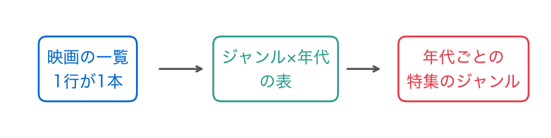

- 映画の一覧から表を作り、年代ごとに合わせるジャンルを決める

## 手元のデータ

② 手元のデータ●○○

- MovieLens（Harper & Konstan, 2015）の映画の一覧（ml-latest-small）
- ミネソタ大学の研究グループGroupLensが、研究と教育のために公開
- 再配布は認められていないので、ノートの中でGroupLensのページから取ってくる

## 1行が1本の映画

② 手元のデータ●●○

- 題名の後ろのかっこに、公開年が入っている
- ジャンルの列には、「|」で区切った複数のジャンルが入っている
- 答えの列はない

## データをのぞく

② 手元のデータ●●●

```
   movieId                    title                                       genres
0        1         Toy Story (1995)  Adventure|Animation|Children|Comedy|Fantasy
1        2           Jumanji (1995)                   Adventure|Children|Fantasy
2        3  Grumpier Old Men (1995)                               Comedy|Romance
(9742, 3)
```

- 9742本の映画。1本目の『Toy Story』には、5つのジャンルが付いている

## 最後に出す答え

③ 今日の問い●○

- 年代ごとに、合わせるジャンルを並べた企画の一文
- 根拠として、1枚の地図と、その年代に多いジャンルを示す倍率

## 今日の問い

③ 今日の問い●●

年代別の特集に、どのジャンルを合わせればよいか？

## もう1つのねらい：1本を通す

④ もう1つのねらい●○

- これまでの書き方を組み合わせて、データの読み込みから報告の一文まで、1本の分析を自分で通せるようになる

## これまでの書き方を、組み合わせる

④ もう1つのねらい●●

- 新しく出すのは、一覧を表にする書き方（`str.extract`・`str.split`・`explode`）と`np.outer`
- 並べ替え検定・特異値分解・`def`・辞書・f-stringは、これまでの回のおさらい

## 今日の道筋

⑤ 今日の問い●

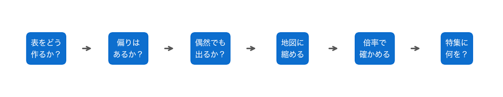

- 6つの小さな問いに答えていく

# 0. 準備

## まずは道具と、映画の一覧

- 第14回のノートを開き、上から順にセルを実行する
- 道具を呼び出し、映画の一覧を取ってくる

## お手本：道具を呼び出す

0節 ① 道具●

```python
import numpy as np
import pandas as pd
import matplotlib.pyplot as plt
```

- 今日も、numpy・pandas・matplotlibの3つが中心

## お手本：映画の一覧を取ってくる

0節 ② 取ってくる●○○

```python
import os
import shutil
import urllib.request
WORK = '/content'   # Colab の作業場所
URL = ('https://files.grouplens.org/datasets/movielens/'
       'ml-latest-small.zip')
if not os.path.exists(f'{WORK}/ml-latest-small'):   # まだなら
    urllib.request.urlretrieve(URL, f'{WORK}/ml.zip')
    shutil.unpack_archive(f'{WORK}/ml.zip', WORK)
print(sorted(os.listdir(f'{WORK}/ml-latest-small')))
```

## 1行ずつ読む

0節 ② 取ってくる●●○

- `urllib.request.urlretrieve(URL, 保存先)`：URLのファイルを保存する
- `shutil.unpack_archive(zip, 展開先)`：zipを展開する
- `os.path.exists`：まだ取ってきていないときだけ取ってくる（第12回）

## 5つのファイル

0節 ② 取ってくる●●●

```
['README.txt', 'links.csv', 'movies.csv', 'ratings.csv', 'tags.csv']
```

- 今日使うのは、映画の一覧`movies.csv`だけ
- 評価の記録（`ratings.csv`）などは使わない

## やってみよう：0節

0節 ③ 確かめる●

- 0節のセルを上から実行する

動画の人は、ここで一時停止。

# 1. ジャンルと年代の表を、どう作るか？

## まず、一覧を表にする

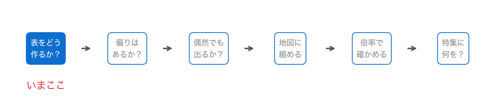

- 映画の一覧が手に入った。まず、ジャンルと年代の表を作る

## お手本：映画の一覧を読む

1節 ① 読む●○

```python
mv = pd.read_csv(f'{WORK}/ml-latest-small/movies.csv')
print(mv.shape)
mv.head(3)
```

- 役割：映画の一覧を読み、大きさと先頭の3本を表示する

## 9742本の映画

1節 ① 読む●●

```
(9742, 3)
   movieId                    title                                       genres
0        1         Toy Story (1995)  Adventure|Animation|Children|Comedy|Fantasy
1        2           Jumanji (1995)                   Adventure|Children|Fantasy
2        3  Grumpier Old Men (1995)                               Comedy|Romance
```

- `title`の後ろのかっこに公開年、`genres`に「|」で区切ったジャンル

## 年代は、どこにある？

1節 ② 公開年●○○○○○

- 年代で数えたいのに、公開年の列がない
- 公開年は、題名の中にある：`Toy Story (1995)`
- 題名の文字から、4けたの数字を取り出せばよい

## 新しい書き方：str.extract

1節 ② 公開年●●○○○○

- `str.extract(型)`：文字の列から、型に合う部分を取り出す
- 型は、正規表現という書き方で書く
- 今日使う型は、1つだけ

## 型を読む

1節 ② 公開年●●●○○○

```python
r'\((\d{4})\)'
```

- `\(`と`\)`：かっこの文字そのもの
- `\d{4}`：4けたの数字
- 内側の`( )`で囲んだ部分（4けたの数字）を、取り出す

## 小さな例で試す

1節 ② 公開年●●●●○○

```python
s = pd.Series(['Toy Story (1995)', 'Heat (1995)', 'Up'])
s.str.extract(r'\((\d{4})\)')[0]
```

```
0    1995
1    1995
2     NaN
```

- 結果は表で返るので、`[0]`で1列目を取り出す。型に合わない`'Up'`は`NaN`

## お手本：公開年を取り出す

1節 ② 公開年●●●●●○

```python
mv['年'] = mv['title'].str.extract(r'\((\d{4})\)')[0]
print(mv['年'].isna().sum())
mv = mv.dropna(subset=['年'])
mv['年'] = mv['年'].astype(int)
print(mv['年'].min(), mv['年'].max())
```

- `dropna(subset=['年'])`：`年`が欠測の行を除く（第6回）

## 13本は、公開年なし

1節 ② 公開年●●●●●●

```
13
1902 2018
```

- 13本は、題名に公開年がなかった
- 残りの映画は、1902年から2018年まで

## お手本：10年ごとの年代にする

1節 ③ 年代●○○○

```python
mv['年代'] = mv['年'] // 10 * 10
mv['年代'].value_counts().sort_index()
```

- `//`：割り算の商（小数点以下を切り捨てた答え）
- `1995 // 10`は199。10を掛けると1990

## 古い年代は、少ない

1節 ③ 年代●●○○

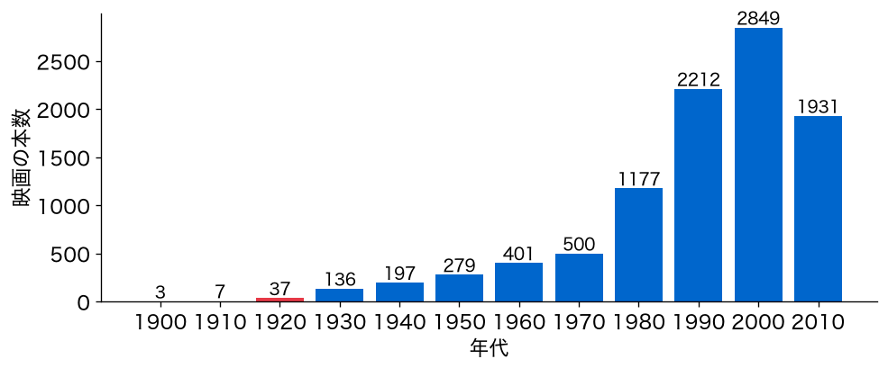

- 1920年代までは、3本・7本・37本しかない

## 1930年代からにする

1節 ③ 年代●●●○

- 本数が少なすぎると、割合が大きく揺れる
- 1930年代から2010年代までの、9つの年代を使う
- 2010年代は、2018年までの映画

## お手本：1930年代から

1節 ③ 年代●●●●

```python
m = mv[mv['年代'] >= 1930].copy()
print(len(m))
```

```
9682
```

- 9682本。`.copy()`で、絞った表を別の表として作る（第12回）

## ジャンルは、1つの文字の中

1節 ④ ジャンル●○○○○

- `genres`は、`'Adventure|Animation|Children|Comedy|Fantasy'`のような1つの文字
- このままでは、ジャンルごとに数えられない
- 1行に1つのジャンルの形に直す

## 新しい書き方：splitとexplode

1節 ④ ジャンル●●○○○

- `str.split('|')`：文字を「|」で区切って、リストにする
- `explode('列')`：リストの入った列を、要素ごとの行に分ける
- ほかの列は同じ値を写す。行の番号も、元の行の番号のまま

## 1本が5行になる

1節 ④ ジャンル●●●○○

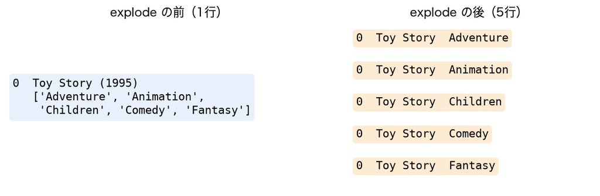

## お手本：ジャンルを1行1つに

1節 ④ ジャンル●●●●○

```python
m['ジャンル'] = m['genres'].str.split('|')
e = m.explode('ジャンル')
print(len(m), len(e))
e[['title', '年代', 'ジャンル']].head(6)
```

- 役割：ジャンルをリストにし、1行1ジャンルの表`e`を作る

## 9682行が21972行に

1節 ④ ジャンル●●●●●

```
9682 21972
              title    年代       ジャンル
0  Toy Story (1995)  1990  Adventure
0  Toy Story (1995)  1990  Animation
0  Toy Story (1995)  1990   Children
0  Toy Story (1995)  1990     Comedy
0  Toy Story (1995)  1990    Fantasy
1    Jumanji (1995)  1990  Adventure
```

- 『Toy Story』は5行に分かれ、5行とも行の番号は0のまま

## お手本：多い10ジャンルに絞る

1節 ⑤ 絞る●○

```python
top = e['ジャンル'].value_counts().index[:10]
e = e[e['ジャンル'].isin(top)]
print(e['ジャンル'].value_counts())
```

- `value_counts()`は多い順に並ぶので、`index[:10]`が多い10ジャンル
- `isin(リスト)`：リストのどれかに当てはまる行で`True`（第10回）

## 10ジャンル

1節 ⑤ 絞る●●

```
ジャンル
Drama        4340
Comedy       3737
Thriller     1890
Action       1822
Romance      1586
Adventure    1256
Crime        1196
Horror        973
Sci-Fi        973
Fantasy       771
```

- ドラマ（Drama）とコメディ（Comedy）が多い。ファンタジー（Fantasy）までを使う

## おさらい：pd.crosstab

1節 ⑥ クロス表●○○

```python
pd.crosstab(pd.Series(['A', 'A', 'B']), pd.Series([1, 2, 2]))
```

```
col_0  1  2
row_0
A      1  1
B      0  1
```

- 2つの区分の組み合わせごとに、行の数を数えた表（クロス表）を作る（第11回）

## お手本：ジャンルと年代のクロス表

1節 ⑥ クロス表●●○

```python
ct = pd.crosstab(e['ジャンル'], e['年代'])
ct
```

- 役割：ジャンル（行）と年代（列）のクロス表`ct`を作る

## 10行9列の表

1節 ⑥ クロス表●●●

```
年代         1930  1940  1950  1960  1970  1980  1990  2000  2010
ジャンル
Action        8     8    15    56   103   227   392   549   464
Adventure    13    13    30    65    71   170   239   363   292
Comedy       53    55    67   132   155   492   890  1135   758
Crime        15    29    29    43    70   124   264   404   218
Drama        74   118   146   192   225   439  1038  1365   743
Fantasy       8    11    11    25    31   106   149   252   178
Horror        9    12    25    40    63   176   160   298   190
Romance      48    54    64    60    44   154   422   523   217
Sci-Fi        3     2    35    35    59   156   173   266   244
Thriller     11    32    32    49    95   180   420   654   417
```

- 1930年代のロマンス（Romance）は48本、1940年代のSF（Sci-Fi）は2本

## 合計は、映画の本数？

1節 ⑦ 確かめる●○○○○○

- 表を作ったら、合計を確かめる
- 表の合計は、表に入った映画の本数と同じになるはず？

## 確かめる：合計と本数

1節 ⑦ 確かめる●●○○○○

```python
print(ct.to_numpy().sum())
print(e.index.nunique())
print((e.index.value_counts() > 1).mean().round(3))
```

- `e`の行の番号は、元の映画の番号のまま
- `nunique()`：種類の数。つまり、表に入った映画の本数

## 合計が、本数より多い

1節 ⑦ 確かめる●●●○○○

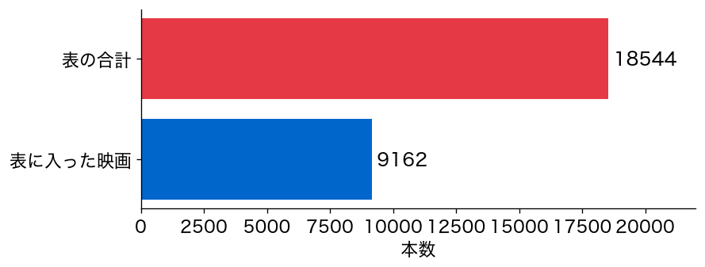

```
18544
9162
0.655
```

## 重ねて数えている

1節 ⑦ 確かめる●●●●○○

- 65.5%の映画が、2つ以上の升で数えられている
- 1つの数が1本の別の映画、という表ではない

## 何に困るのか

1節 ⑦ 確かめる●●●●●○

- 年代ごとのジャンルの割合を見るには、困らない
- 表の数を「別々の映画の本数」として扱う計算には、注意が要る

## やってみよう：1節

1節 ⑦ 確かめる●●●●●●

- 1節のお手本を上から実行する
- `index[:10]`を`index[:12]`にして、12ジャンルの表も見てみる（見たら10に戻す）

動画の人は、ここで一時停止。

# 2. 年代によって、ジャンルは偏っているか？

## 年代で、割合は違うか

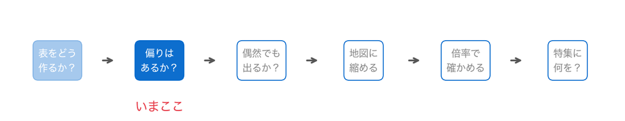

- ジャンルと年代のクロス表ができた
- 年代によって、ジャンルの割合は違うのか

## 割合で並べると

2節 ① 期待度数●○○○○○○○

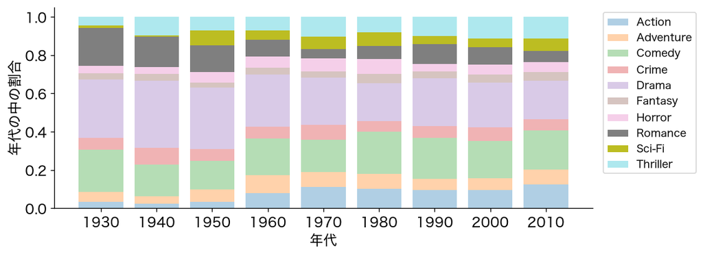

- 年代の中で、ジャンルが占める割合。ロマンスとSFだけ濃くした

## 古いほどロマンス、新しいほどSF？

2節 ① 期待度数●●○○○○○○

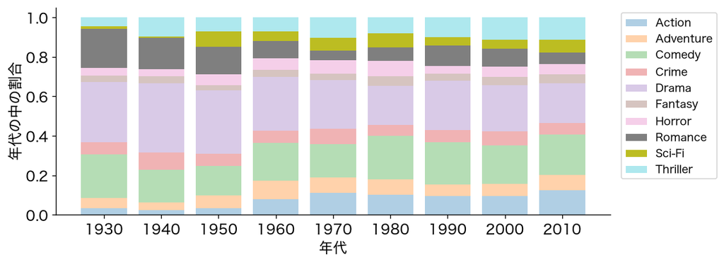

- ロマンスは古い年代で厚く、SFは1940年代までほとんどない
- どれくらい違えば「偏っている」と言えるか

## 独立なら、割合は同じ

2節 ① 期待度数●●●○○○○○

- ジャンルと年代に関係がない（独立）なら、どの年代でも、ジャンルの割合は全体と同じ
- そのとき升に入るはずの本数を、期待度数と呼ぶ

## 期待度数の式

2節 ① 期待度数●●●●○○○○

$$E_{ij} = \frac{(\text{行}\ i\ \text{の合計}) \times (\text{列}\ j\ \text{の合計})}{\text{総数}\ n}$$

- ロマンスが全体に占める割合で、1930年代の中にもロマンスがあるはず、という計算

## 新しい書き方：np.outer

2節 ① 期待度数●●●●●○○○

```python
np.outer([1, 2], [10, 20, 30])
```

```
[[10 20 30]
 [20 40 60]]
```

- `a`の要素と`b`の要素を、総当たりで掛けた表を作る

## お手本：期待度数の表

2節 ① 期待度数●●●●●●○○

```python
O = ct.to_numpy()
n = O.sum()
E = np.outer(O.sum(axis=1), O.sum(axis=0)) / n
print(E.shape)
print(O.sum(axis=1)[7], O.sum(axis=0)[0], n)
print(E[7, 0].round(1), O[7, 0])
```

## 1行ずつ読む

2節 ① 期待度数●●●●●●●○

- `O`：クロス表を配列にしたもの（観測度数）
- `O.sum(axis=1)`は行ごと、`O.sum(axis=0)`は列ごとの合計
- `[7, 0]`：ロマンスは上から8行目（番号7）、1930年代は1列目（番号0）

## 20.7本のはずが、48本

2節 ① 期待度数●●●●●●●●

```
(10, 9)
1586 242 18544
20.7 48
```

- 1586 × 242 ÷ 18544で、期待度数は20.7本
- 実際は48本。期待の2倍以上

## ずれを、どう集めるか

2節 ② カイ二乗●○○○○

- 升ごとのずれ（実際 − 期待）は、本数の多い升ほど大きく出る
- ずれを期待度数の平方根で割って、そろえる

## 標準化残差

2節 ② カイ二乗●●○○○

$$z_{ij} = \frac{O_{ij} - E_{ij}}{\sqrt{E_{ij}}}$$

- $O_{ij}$が実際の本数、$E_{ij}$が期待度数
- この$z_{ij}$を、標準化残差と呼ぶ

## カイ二乗統計量

2節 ② カイ二乗●●●○○

$$\chi^2 = \sum_{i}\sum_{j} z_{ij}^2$$

- 標準化残差の二乗を、すべての升で足した数
- ずれが大きいほど、大きくなる

## お手本：標準化残差とカイ二乗

2節 ② カイ二乗●●●●○

```python
Z = (O - E) / np.sqrt(E)
chi = (Z ** 2).sum()
print(Z[7, 0].round(2))
print(chi.round(1))
```

- 配列どうしの計算なので、90個の升をまとめて計算する

## 548.4

2節 ② カイ二乗●●●●●

```
6.0
548.4
```

- 1930年代のロマンスの標準化残差は6.0。ずれが大きい升
- カイ二乗統計量は548.4

## TODO①：scipyで確かめる

2節 ③ 確かめる●○○○

```python
# TODO: chi2_contingency で、カイ二乗統計量と p値を出す
# ヒント: from scipy.stats import chi2_contingency
#         chi_s, p, dof, E_s = chi2_contingency(ct)
#         print(round(chi_s, 1), dof, p)
#         print(np.allclose(E, E_s))
...
```

- `chi2_contingency`は、カイ二乗統計量・p値・自由度・期待度数の4つを返す

## やってみよう：2節とTODO①

2節 ③ 確かめる●●○○

- 2節のお手本を上から実行する
- TODO①で、scipyでも548.4になるか、p値はいくつかを確かめる

動画の人は、ここで一時停止。

## 答え合わせ：TODO①

2節 ③ 確かめる●●●○

```python
from scipy.stats import chi2_contingency
chi_s, p, dof, E_s = chi2_contingency(ct)
print(round(chi_s, 1), dof, p)
print(np.allclose(E, E_s))
```

```
548.4 72 1.97641130983306e-74
True
```

## p値は、とても小さい

2節 ③ 確かめる●●●●

- カイ二乗統計量は同じ548.4、自由度は72
- p値は$10^{-74}$ほど。期待度数も`E`と一致する

## 式のp値は、使えるか？

2節 ④ 前提●○

- このp値は、式（カイ二乗分布）から求めた値
- 式は「1つの数が1本の別の映画」という表を前提にしている

## 前提が崩れている

2節 ④ 前提●●

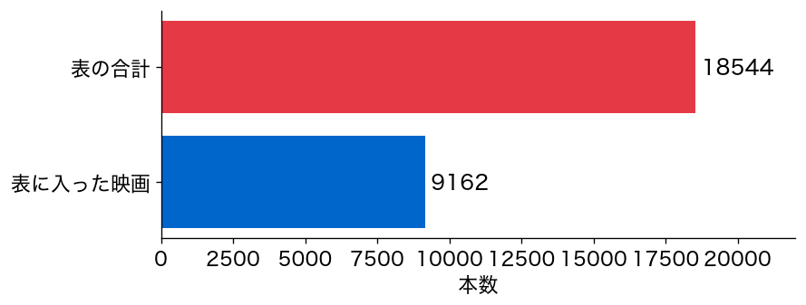

- この表は、65.5%の映画を重ねて数えている
- 式のp値は、そのままでは使えない

# 3. その偏りは、偶然でも出るか？

## 式の代わりに、並べ替えで

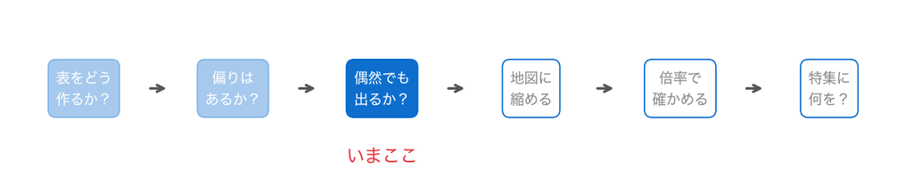

- カイ二乗統計量は548.4。けれども、式のp値はこの表には使えない
- この大きさは、偶然でも出るのか。前回の並べ替え検定で確かめる

## 帰無仮説：関係がない

3節 ① 並べ替える●○○○○

- 帰無仮説は、「ジャンルと年代は関係がない」
- 関係がないなら、どの映画がどの年代に作られたかを入れ替えても、表は偶然のずれしか変わらない

## 何を並べ替えるか

3節 ① 並べ替える●●○○○

- 並べ替えるのは、映画ごとの年代
- 1本の映画の複数のジャンルは、ひとまとまりのまま動かす

## 4本で描く

3節 ① 並べ替える●●●○○

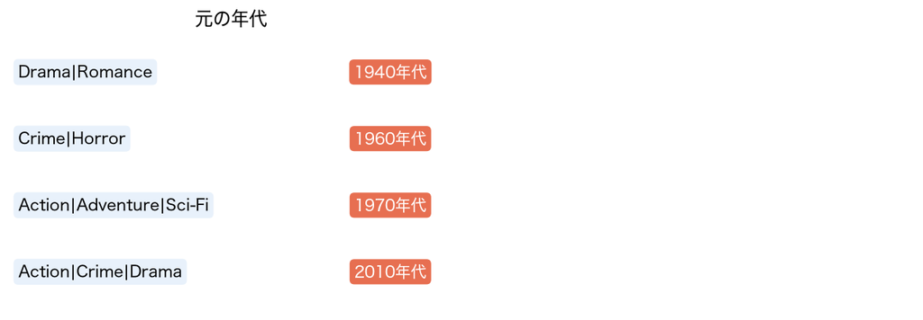

- 4本の映画の、ジャンル（先頭の3つまで）と年代

## 年代だけを入れ替える

3節 ① 並べ替える●●●●○

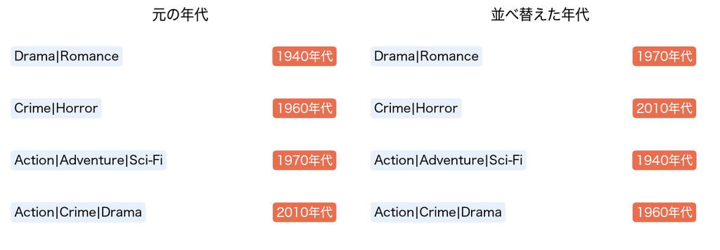

- ジャンルの組はそのまま。年代だけを、映画の間で入れ替える

## 重ねて数えるのも、そのまま

3節 ① 並べ替える●●●●●

- 並べ替えた後も、表は同じ数え方（重ねて数える）で作る
- 元の表と同じ数え方のまま、偶然ならどれくらいのカイ二乗統計量が出るかが分かる

## 表づくりを、やり直す

3節 ② 関数に●○○○

- 並べ替えるたびに、1節の表づくりと、2節のカイ二乗統計量の計算をやり直す
- どちらも2回目なので、関数にまとめる

## お手本：2つの関数

3節 ② 関数に●●○○

```python
def make_table(m):
    e = m.explode('ジャンル')
    e = e[e['ジャンル'].isin(top)]
    return pd.crosstab(e['ジャンル'], e['年代'])


def chi2(ct):
    O = ct.to_numpy()
    E = np.outer(O.sum(axis=1), O.sum(axis=0)) / O.sum()
    return (((O - E) / np.sqrt(E)) ** 2).sum()


obs = chi2(make_table(m))
print(obs.round(1))
```

## ブロックで読む

3節 ② 関数に●●●○

- `make_table(m)`：映画の表`m`から、クロス表を作る。1節のセルを並べただけ
- `chi2(ct)`：クロス表から、カイ二乗統計量を出す。2節のセルを並べただけ
- `obs`：元の表のカイ二乗統計量（observedの略。観測した値）

## 元の表で548.4

3節 ② 関数に●●●●

```
548.4
```

- 2節と同じ値。関数にまとめても、手順は変わっていない

## お手本：1回並べ替える

3節 ③ 1回●○○

```python
rng = np.random.default_rng(0)
m2 = m.copy()
m2['年代'] = rng.permutation(m['年代'].to_numpy())
print(chi2(make_table(m2)).round(1))
```

- 役割：映画ごとの年代を並べ替えた表`m2`を作り、カイ二乗統計量を出す

## 1行ずつ読む

3節 ③ 1回●●○

- `np.random.default_rng(0)`：シード0の乱数生成器（第13回）
- `m.copy()`：写しを作る。元の`m`は変えない
- `rng.permutation(...)`：年代の並びを、ばらばらに並べ替える

## 48.7

3節 ③ 1回●●●

```
48.7
```

- 並べ替えると、カイ二乗統計量は48.7
- 元の548.4より、ずっと小さい

## お手本：1000回並べ替える

3節 ④ 1000回●○○○

```python
rng = np.random.default_rng(0)
perm = []
for r in range(1000):
    m2 = m.copy()
    m2['年代'] = rng.permutation(m['年代'].to_numpy())
    perm.append(chi2(make_table(m2)))
perm = np.array(perm)
plt.hist(perm, bins=30)
plt.axvline(obs, color='red')
plt.xlabel('並べ替えたときの、カイ二乗統計量')
plt.ylabel('回数')
plt.show()
print(perm.mean().round(1), perm.max().round(1))
```

## ブロックで読む

3節 ④ 1000回●●○○

- くり返す中身：1回並べ替えるセルの2行と、`append`でためる1行
- 1回ごとに表を作り直すので、前回の1万回より少ない1000回。少し時間がかかる
- 出力：ヒストグラムと、`perm`の平均と最大

## 山は、どこにある？

3節 ④ 1000回●●●○

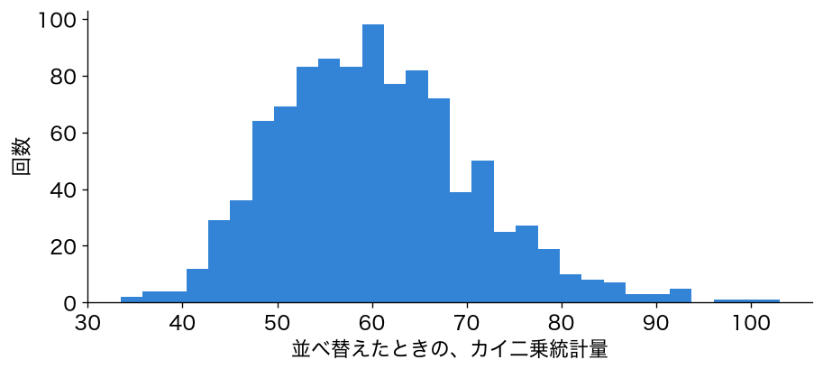

## 山は、548.4のはるか左

3節 ④ 1000回●●●●

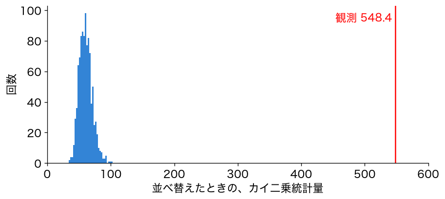

```
60.3 103.0
```

- 並べ替えたときは、平均60.3、いちばん大きくても103.0

## TODO②：548.4以上は何回？

3節 ⑤ p値●○○○○

```python
# TODO: perm が obs 以上になった回数と割合を出す
# ヒント: big = perm >= obs
#         print(big.sum())
#         print(np.mean(big))
...
```

- `perm`が`obs`以上になった回数と、その割合（p値）

## やってみよう：3節とTODO②

3節 ⑤ p値●●○○○

- 3節のお手本を上から実行する（1000回のセルは、少し待つ）
- TODO②で、548.4以上が何回出たかを数える

動画の人は、ここで一時停止。

## 答え合わせ：TODO②

3節 ⑤ p値●●●○○

```python
big = perm >= obs
print(big.sum())
print(np.mean(big))
```

```
0
0.0
```

## 1000回のうち、0回

3節 ⑤ p値●●●●○

- p値は、1000回の並べ替えでは1/1000より小さい、としか言えない
- それでも、関係がなければ、548.4のような大きさは、まず出ない
- 年代によって、ジャンルは偏っている

## 結論は同じ、確かめ方が違う

3節 ⑤ p値●●●●●

- 結論は、式のp値と同じ
- 今度は、重ねて数えた表の数え方のまま確かめた

# 4. 偏りの表を、どう1枚の地図に縮めるか？

## どこが、偏っているのか

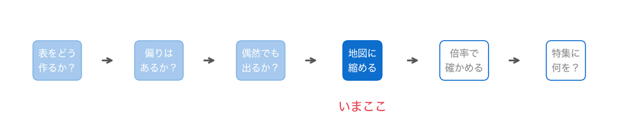

- 偏りは、偶然では出ないと分かった
- けれども、標準化残差の表`Z`は10行9列、90個の升。そのままでは読みきれない

## 第9回：特異値分解で縮めた

4節 ① 対応分析●○○

- 第9回では、顔の画像の表を、特異値分解で少ない数の向きに縮めた
- 対応分析は、同じ計算を、標準化残差の表`Z`にかける

## 3つに分ける

4節 ① 対応分析●●○

- `Z`を、行の向き`U`・特異値`d`・列の向き`Vt`の3つに分ける
- 特異値の二乗の和は、カイ二乗統計量と同じになる
- 特異値の二乗の割合が、その次元で表せるずれの割合（寄与率）

## 手順だけを使う

4節 ① 対応分析●●●

- なぜこの計算でよいか（対応分析の理論）は、ここでは扱わない
- 手順を使い、出てきた地図を読むことに集中する

## おさらい：np.linalg.svd

4節 ② 特異値分解●○○○

```python
U, d, Vt = np.linalg.svd(Z, full_matrices=False)
```

- 表を`U`・`d`・`Vt`の3つに分ける（第9回）
- `d`は、大きい順に並んだ特異値

## お手本：特異値分解する

4節 ② 特異値分解●●○○

```python
U, d, Vt = np.linalg.svd(Z, full_matrices=False)
print(d.round(2))
print((d ** 2).sum().round(1))
```

- 役割：`Z`を特異値分解し、特異値と、その二乗の和を表示する

## 二乗の和が、548.4

4節 ② 特異値分解●●●○

```
[19.21  9.55  6.7   4.61  3.69  2.68  1.05  0.53  0.  ]
548.4
```

- 特異値の二乗の和は548.4で、カイ二乗統計量と一致した
- ずれ全体を、9つの次元に分けたことになる

## 最後は0

4節 ② 特異値分解●●●●

- 9つめの特異値は0
- ずれ（$O - E$）は、どの行で足しても、どの列で足しても0になる
- その分、次元が1つ減る

## 寄与率

4節 ③ 寄与率●○○○○

$$\text{次元}\ k\ \text{の寄与率} = \frac{d_k^2}{\sum_l d_l^2}$$

- その次元が、ずれ全体の何割を表すか
- 主成分分析の寄与率と、同じ考え方

## TODO③：寄与率を出す

4節 ③ 寄与率●●○○○

```python
# TODO: 次元ごとの寄与率を出す
# ヒント: share = d ** 2 / (d ** 2).sum()
#         print(share.round(3))
#         print(share[:2].sum().round(3))
...
```

- 次元1と次元2の寄与率の和も表示する

## やってみよう：4節前半とTODO③

4節 ③ 寄与率●●●○○

- 特異値分解のお手本を実行する
- TODO③で、寄与率を出す

動画の人は、ここで一時停止。

## 答え合わせ：TODO③

4節 ③ 寄与率●●●●○

```python
share = d ** 2 / (d ** 2).sum()
print(share.round(3))
print(share[:2].sum().round(3))
```

```
[0.673 0.166 0.082 0.039 0.025 0.013 0.002 0.001 0.   ]
0.839
```

## 2つの次元で、8割以上

4節 ③ 寄与率●●●●●

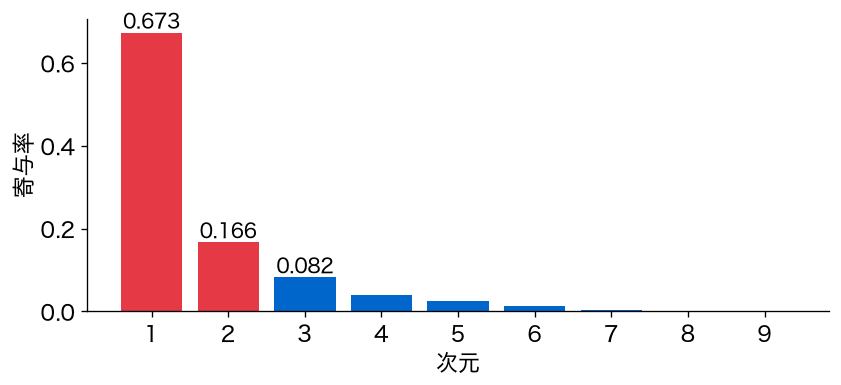

- 次元1が67.3%、次元2が16.6%で、合わせて83.9%
- この2つで、地図を描く

## 地図の座標

4節 ④ 座標●○○○○

$$a_i = \frac{U_{i1}\, d_1}{\sqrt{\text{行}\ i\ \text{の合計}}}, \qquad b_j = \frac{V_{j1}\, d_1}{\sqrt{\text{列}\ j\ \text{の合計}}}$$

- $a_i$はジャンル$i$の、$b_j$は年代$j$の、次元1の座標
- 次元2は、添え字の1を2に変える

## なぜ、合計の平方根で割るのか

4節 ④ 座標●●○○○

- 本数の多いジャンルや年代ほど、`Z`は大きく出る
- 合計の平方根で割って、割合の偏りにそろえる
- 原点は全体の平均の割合。原点から離れているほど、割合の偏りが大きい

## お手本：ジャンルと年代の座標

4節 ④ 座標●●●○○

```python
rs = np.sqrt(O.sum(axis=1))   # 行（ジャンル）の合計の平方根
cs = np.sqrt(O.sum(axis=0))   # 列（年代）の合計の平方根
g = pd.DataFrame({'次元1': U[:, 0] * d[0] / rs,
                  '次元2': U[:, 1] * d[1] / rs}, index=ct.index)
dc = pd.DataFrame({'次元1': Vt[0] * d[0] / cs,
                   '次元2': Vt[1] * d[1] / cs}, index=ct.columns)
print(g.round(3))
print(dc.round(3))
```

## 1行ずつ読む

4節 ④ 座標●●●●○

- `U[:, 0]`：`U`の1列目（次元1の、行の向き）
- `Vt[0]`：`Vt`の1行目（次元1の、列の向き）
- `pd.DataFrame({列名: 値, ...}, index=...)`：辞書から、名前つきの表を作る

## 座標の表

4節 ④ 座標●●●●●

```
             次元1    次元2
ジャンル
Action    -0.193  0.079
Adventure -0.116 -0.071
Comedy    -0.021  0.017
Crime      0.052  0.026
Drama      0.127 -0.021
Fantasy   -0.106  0.024
Horror    -0.135 -0.165
Romance    0.292 -0.015
Sci-Fi    -0.213 -0.125
Thriller  -0.042  0.120
```

```
        次元1    次元2
年代
1930  0.494 -0.095
1940  0.499 -0.000
1950  0.275 -0.234
1960  0.055 -0.126
1970 -0.114 -0.052
1980 -0.136 -0.116
1990  0.093  0.049
2000  0.029  0.034
2010 -0.161  0.033
```

- 左がジャンルの座標`g`、右が年代の座標`dc`

## お手本：地図を描く

4節 ⑤ 地図●○○○○

```python
plt.scatter(g['次元1'], g['次元2'], color='tab:blue')
for name in g.index:
    plt.text(g.loc[name, '次元1'], g.loc[name, '次元2'], name)
plt.scatter(dc['次元1'], dc['次元2'], color='tab:red', marker='^')
for dec in dc.index:
    plt.text(dc.loc[dec, '次元1'], dc.loc[dec, '次元2'], str(dec),
             color='tab:red')
plt.axhline(0, color='gray', lw=0.5)
plt.axvline(0, color='gray', lw=0.5)
plt.xlabel('次元1')
plt.ylabel('次元2')
plt.show()
```

## 1行ずつ読む

4節 ⑤ 地図●●○○○

- ジャンルは青い丸、年代は赤い三角
- `plt.text(x, y, 文字)`：点の位置に名前を書く。年代は数なので`str`で文字に
- `plt.axhline`・`plt.axvline`：原点を通る横と縦の線

## 1枚の地図

4節 ⑤ 地図●●●○○

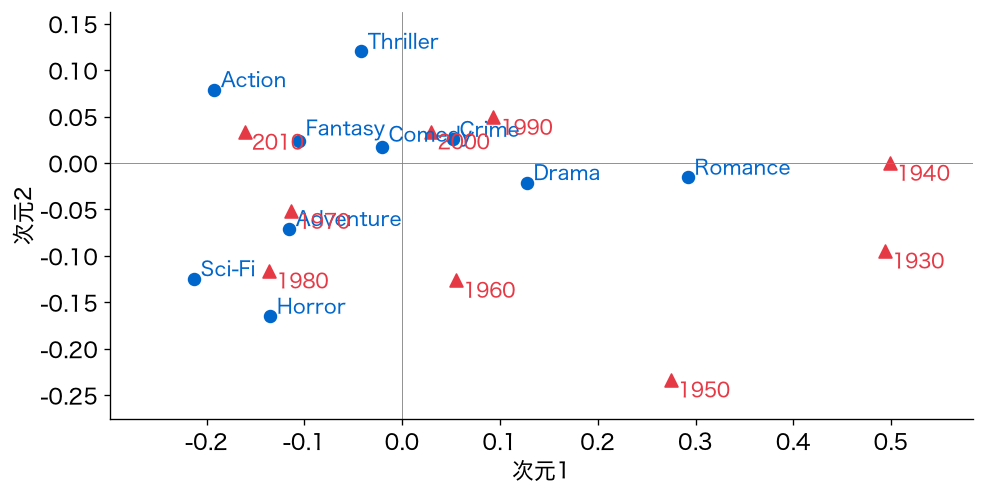

## 右と左は、反転しうる

4節 ⑤ 地図●●●●○

- 特異値分解の向きの符号は、計算の道具によって反転することがある
- 読むのは、点どうしの並び方と、原点からの離れ方

## やってみよう：4節

4節 ⑤ 地図●●●●●

- 4節のお手本を上から実行し、地図を描く
- `plt.figure(figsize=(9, 6))`を地図のセルの先頭に足して、大きく描いてみる

動画の人は、ここで一時停止。

# 5. 地図の読みは、倍率で確かめられるか？

## 地図を読み、数で確かめる

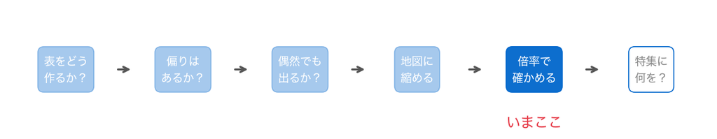

- 地図ができた。この地図を読む
- 読んだことは、表の数でも確かめる

## 年代は、どう並んでいる？

5節 ① 時代の軸●○

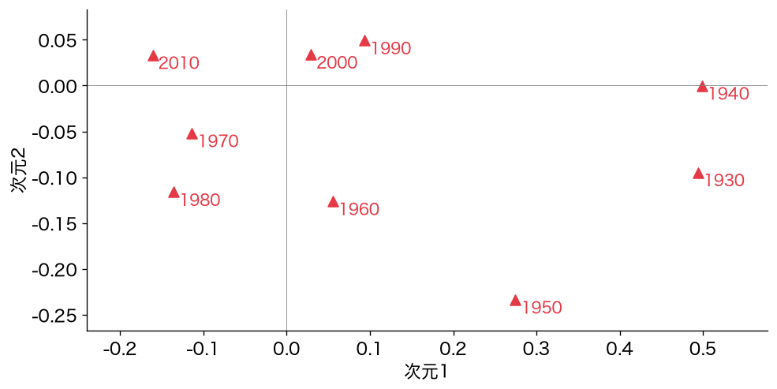

## 次元1は、時代の軸

5節 ① 時代の軸●●

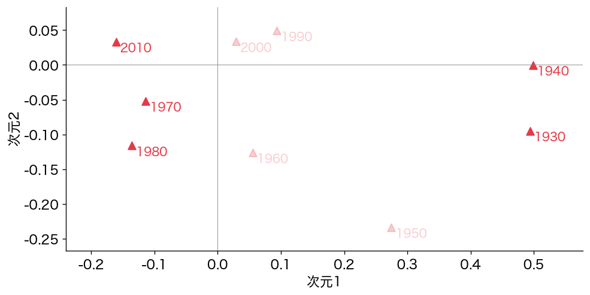

- 右の端に1930年代（0.494）と1940年代（0.499）
- 左に2010年代（−0.161）・1980年代（−0.136）・1970年代（−0.114）

## ジャンルは？

5節 ② ジャンル●○

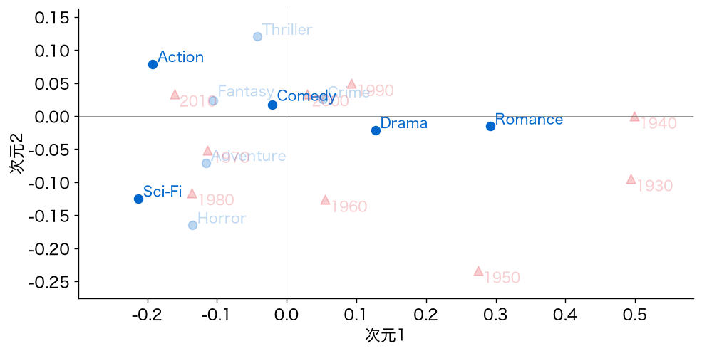

## 古い側にロマンス、新しい側にSF

5節 ② ジャンル●●

- 右（古い年代の側）：ロマンス（0.292）とドラマ（0.127）
- 左（新しい年代の側）：SF（−0.213）とアクション（−0.193）
- コメディ（−0.021）は原点の近く。どの年代にも同じくらいある

## 1990年代が、1960年代より右？

5節 ③ 原点●○○○○

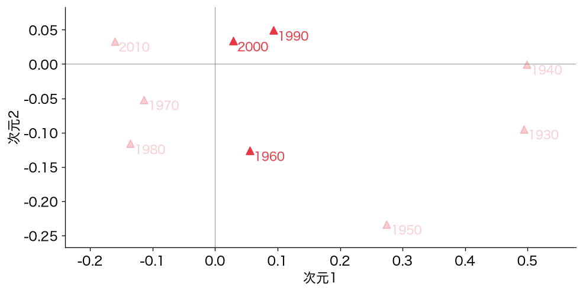

- 1990年代（0.093）は、1960年代（0.055）より右。2000年代（0.029）も原点のすぐ右

## 確かめる：年代の割合

5節 ③ 原点●●○○○

```python
print((O.sum(axis=0) / n).round(3))
```

- 役割：年代ごとの、表の合計に占める割合を出す

## 2つで、半分を超える

5節 ③ 原点●●●○○

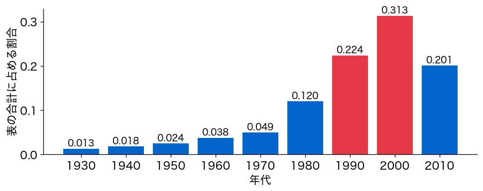

- 1990年代が22.4%、2000年代が31.3%

## だから、原点の近く

5節 ③ 原点●●●●○

- 原点は、全体の平均の割合
- 全体の半分を占める年代の割合は、平均に近くなる
- 1990年代が1960年代より古い、ということではない

## 本数ではなく、割合の違い

5節 ③ 原点●●●●●

- 2010年代も全体の20.1%を占めるが、左の端にいる
- 地図の位置を決めるのは、その年代のジャンルの割合が、全体とどれだけ違うか

## お手本：実際 ÷ 期待の倍率

5節 ④ 倍率●○○○○

```python
ratio = (ct / E).round(2)
ratio
```

- 表を配列で割ると、升ごとに割り算される
- 1より大きければ、そのジャンルが、その年代に期待より多い

## 倍率の表

5節 ④ 倍率●●○○○

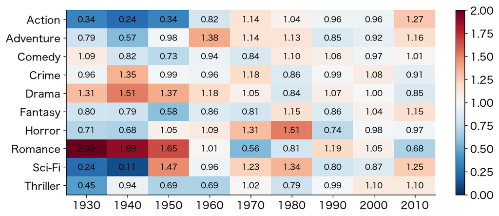

- 赤いほど期待より多く、青いほど少ない

## 古い年代：ロマンスとドラマ

5節 ④ 倍率●●●○○

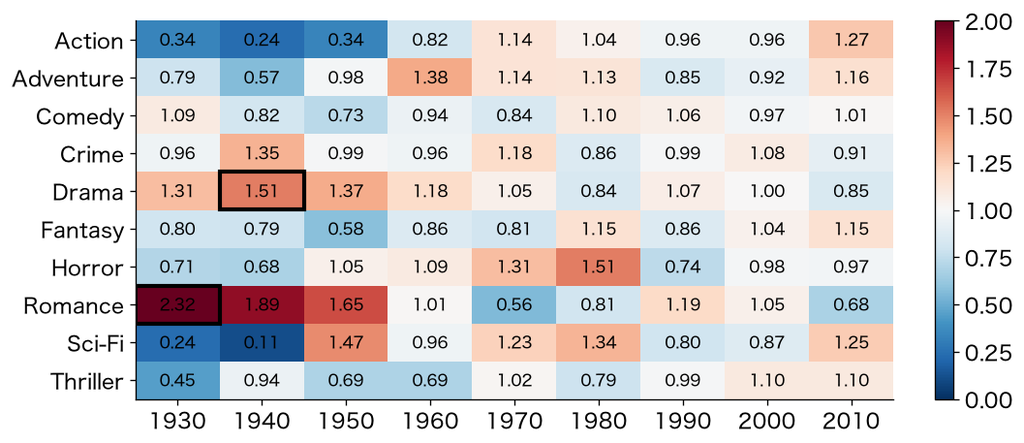

- 1930年代のロマンスは2.32倍、1940年代のドラマは1.51倍

## 新しい年代：ホラーとSF

5節 ④ 倍率●●●●○

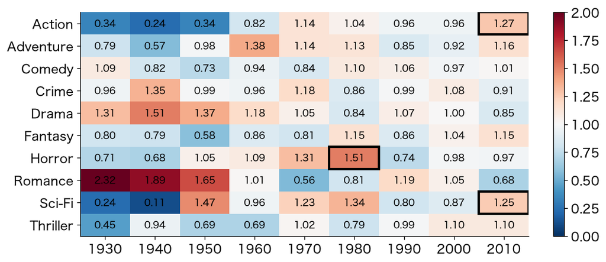

- 1980年代のホラー（Horror）は1.51倍、2010年代のアクションは1.27倍、SFは1.25倍
- 地図の読みと合っている

## 1990・2000年代は、1に近い

5節 ④ 倍率●●●●●

```python
r9 = ratio[[1990, 2000]]
print(r9.min().min(), r9.max().max())
```

```
0.74 1.19
```

- どのジャンルも、0.74倍から1.19倍に収まる。原点の近くにいたことと合う

## 1940年代のSFは、0.11倍？

5節 ⑤ 少ない升●○

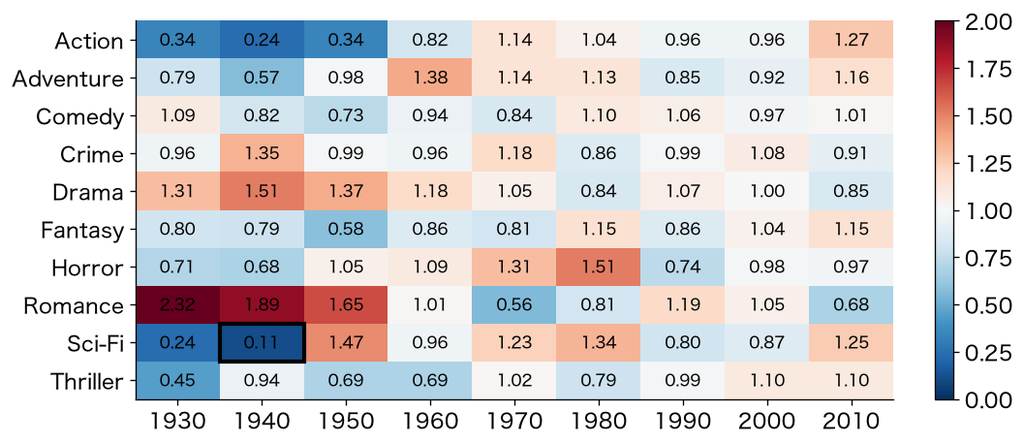

## 2本しかない

5節 ⑤ 少ない升●●

- 1節の表では、1940年代のSFは2本だった
- 1本増えるだけで、倍率は半分ほど大きくなる
- 本数の少ない升の倍率は大きく揺れる。元の本数も見る

## おさらい：forと辞書

5節 ⑥ 辞書に●○○○○

```python
out = {}
for k in [1, 2]:
    out[k] = k * 10
print(out)
```

```
{1: 10, 2: 20}
```

- 空の辞書`{}`に、`out[キー] = 値`で組をためる（第3回）

## TODO④：上位3ジャンル

5節 ⑥ 辞書に●●○○○

```python
# TODO: 1950・1970年代の、倍率の高い3ジャンルを辞書 top3 にためる
# ヒント: top3 = {}
#         for dec in [1950, 1970]:
#             s = ratio[dec].sort_values(ascending=False)
#             top3[dec] = s.head(3).to_dict()
#         print(top3)
...
```

- `{年代: {ジャンル: 倍率}}`の形でためる

## やってみよう：5節とTODO④

5節 ⑥ 辞書に●●●○○

- 5節のお手本を上から実行する
- TODO④で、1950年代と1970年代の上位3ジャンルを辞書にためる

動画の人は、ここで一時停止。

## 答え合わせ：TODO④

5節 ⑥ 辞書に●●●●○

```python
top3 = {}
for dec in [1950, 1970]:
    s = ratio[dec].sort_values(ascending=False)
    top3[dec] = s.head(3).to_dict()
print(top3)
```

[output not shown]

## 1950年代と1970年代

5節 ⑥ 辞書に●●●●●

- 1950年代：ロマンス（1.65倍）・SF（1.47倍）・ドラマ（1.37倍）
- 1970年代：ホラー（1.31倍）・SF（1.23倍）・犯罪もの（Crime、1.18倍）
- 1950年代が右寄り、1970年代が左にあったことと合う

# 6. 年代別の特集に、何を合わせるか？

## 企画の一文にする

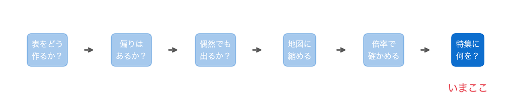

- 地図の読みを、倍率で確かめられた
- 最後に、年代ごとの企画の一文を作り、特集に何を合わせるかを答える

## おさらい：f-string

6節 ① 一文●○○○

```python
n_films = 3
print(f'{n_films}本を選ぶ')
```

```
3本を選ぶ
```

- `f'…'`の中の`{}`に、変数の値を埋めこむ（第4回）

## お手本：1930年代の一文

6節 ① 一文●●○○

```python
r = ratio[1930].sort_values()
print(f'1930年代は {r.index[-1]}（{r.iloc[-1]}倍）を中心に。'
      f'{r.index[0]}（{r.iloc[0]}倍）は少なめに。')
```

- 役割：1930年代の倍率を小さい順に並べ、いちばん高いジャンルと、いちばん低いジャンルで一文を作る

## 1行ずつ読む

6節 ① 一文●●●○

- `sort_values()`：小さい順に並べる
- `r.index[-1]`：最後（いちばん高い）のジャンル。`r.iloc[-1]`はその倍率
- `r.index[0]`・`r.iloc[0]`：最初（いちばん低い）のジャンルと倍率

## 1930年代の一文

6節 ① 一文●●●●

```
1930年代は Romance（2.32倍）を中心に。Sci-Fi（0.24倍）は少なめに。
```

- ロマンス（2.32倍）を中心に、SF（0.24倍）は少なめに

## TODO⑤：すべての年代の一文

6節 ② すべての年代●○○○

```python
# TODO: 9つの年代の、企画の一文を表示する
# ヒント: for dec in ratio.columns:
#             r = ratio[dec].sort_values()
#             print(f'{dec}年代は ...')
...
```

- お手本のセルを`for dec in ratio.columns:`の中に入れる
- `1930`と書いたところを、`dec`に書き換える

## やってみよう：6節とTODO⑤

6節 ② すべての年代●●○○

- 6節のお手本を実行する
- TODO⑤で、9つの年代の一文を表示する

動画の人は、ここで一時停止。

## 答え合わせ：TODO⑤

6節 ② すべての年代●●●○

```python
for dec in ratio.columns:
    r = ratio[dec].sort_values()
    print(f'{dec}年代は {r.index[-1]}（{r.iloc[-1]}倍）を中心に。'
          f'{r.index[0]}（{r.iloc[0]}倍）は少なめに。')
```

## 9つの年代の一文

6節 ② すべての年代●●●●

```
1930年代は Romance（2.32倍）を中心に。Sci-Fi（0.24倍）は少なめに。
1940年代は Romance（1.89倍）を中心に。Sci-Fi（0.11倍）は少なめに。
1950年代は Romance（1.65倍）を中心に。Action（0.34倍）は少なめに。
1960年代は Adventure（1.38倍）を中心に。Thriller（0.69倍）は少なめに。
1970年代は Horror（1.31倍）を中心に。Romance（0.56倍）は少なめに。
1980年代は Horror（1.51倍）を中心に。Thriller（0.79倍）は少なめに。
1990年代は Romance（1.19倍）を中心に。Horror（0.74倍）は少なめに。
2000年代は Thriller（1.1倍）を中心に。Sci-Fi（0.87倍）は少なめに。
2010年代は Action（1.27倍）を中心に。Romance（0.68倍）は少なめに。
```

- 1940年代はロマンス、1960年代は冒険もの（Adventure）、1980年代はホラー、2010年代はアクション

## 答え：古い年代

6節 ③ 答え●○○○

- 1930〜1950年代：ロマンスとドラマ（1930年代のロマンスは2.32倍）
- 1960年代：冒険もの（1.38倍）

## 答え：新しい年代

6節 ③ 答え●●○○

- 1970・1980年代：ホラーとSF（1980年代のホラーは1.51倍）
- 2010年代：アクションとSF（1.27倍と1.25倍）

## 答え：1990・2000年代

6節 ③ 答え●●●○

- どのジャンルも倍率が1に近い（0.74倍から1.19倍）
- ジャンル以外の切り口を考える
- コメディは、どの年代にも同じくらいある

## 根拠

6節 ③ 答え●●●●

- 偏りは、映画ごとに年代を並べ替えた1000回で、一度も出ない大きさ（548.4）
- 地図の次元1は時代の軸で、2つの次元でずれの83.9%を表せる
- 地図の読みは、倍率の表と合っている

## まだ言えないこと①：本数と視聴

6節 ④ まだ言えないこと●○

- 数えたのは作られた本数で、見られた回数ではない
- 特集で視聴が伸びるかは、別のデータで確かめる

## まだ言えないこと②：一覧の範囲

6節 ④ まだ言えないこと●●

- MovieLensの利用者が評価した映画の一覧で、その時代のすべての映画ではない
- 本数の少ない升（1940年代のSFは2本）の倍率は、大きく揺れる

# まとめ

## 今日の道筋を振り返る

⑥ 振り返る●○○○○○

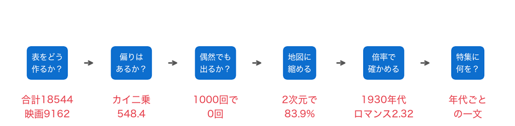

- 6つの小さな問いに答えて、年代ごとの特集のジャンルを決めた

## 今日の歩み

⑥ 振り返る●●○○○○

一覧から表を作る → 期待度数とずれ → 並べ替えで確かめる → 地図に縮める → 倍率で確かめる → 企画の一文

## 今日持ち帰る1文

⑥ 振り返る●●●○○○

区分と区分の表は、独立なら何本になるか（期待度数）と比べて、ずれを読む。ずれが偶然でないことは、並べ替えで確かめる。ずれの表を特異値分解で縮めると、行と列を1枚の地図に置ける。地図で見えたことは、倍率の表で確かめる。

## 今日の要点①：表と検定

⑥ 振り返る●●●●○○

- 表を作ったら、合計と元の本数を比べる
- 重ねて数えた表では、式のp値の前提が崩れる。並べ替え検定なら、同じ数え方のまま確かめられる

## 今日の要点②：地図と倍率

⑥ 振り返る●●●●●○

- 地図の原点は全体の平均の割合。原点から離れているほど、割合の偏りが大きい
- 本数が多いことと、原点から離れていることは別
- 本数の少ない升の倍率は、大きく揺れる

## 今日の要点③：Python

⑥ 振り返る●●●●●●

- `str.extract`・`str.split`・`explode`で、一覧を表にする
- `np.outer`で期待度数を作る
- 並べ替え・特異値分解・辞書・f-stringを組み合わせて、分析を最後まで通す

## 歩み①：道具をそろえる

⑦ 歩み●○○○○

| 回 | 分析 | 新しく出てきた書き方 |
| --- | --- | --- |
| 1 | データを見る（自転車） | 列を選ぶ、条件で絞る、集計 |
| 2 | 回帰と汎化（自転車） | numpyの配列、`for`、`if`、行列の計算 |
| 3 | 前処理（東京の民泊） | `def`、条件で値を置き換える |
| 4 | 評価と解釈（民泊・住宅） | 関数を組み合わせる、f-string |
| 5 | 正則化（住宅） | ドキュメントで引数を読む |

## 歩み②：当てる、縮める

⑦ 歩み●●○○○

| 回 | 分析 | 新しく出てきた書き方 |
| --- | --- | --- |
| 6 | 分類（心臓病） | 配列の比較と`True`・`False`の集計 |
| 7 | 確率としきい値（心臓病） | クラスとメソッド（`fit`・`predict`） |
| 8 | 教師あり解析を一周（遺伝子） | 関数に分けた1本のスクリプト |
| 9 | 主成分分析（顔） | 行列の計算、特異値分解 |
| 10 | 主成分の地図を読む（車） | 関数に分かれたスクリプトを読む |

## 歩み③：分ける、確かめる、地図に

⑦ 歩み●●●○○

| 回 | 分析 | 新しく出てきた書き方 |
| --- | --- | --- |
| 11 | k-means（国） | `while` |
| 12 | 論文のコードを読む（銀河） | 著者のノートとファイルを読む（JSON・`glob`） |
| 13 | 並べ替え検定とブートストラップ（職業訓練） | 乱数でくり返し、結果をためて分布で読む |
| 14 | 対応分析（映画） | これまでの書き方の総ざらい |

## どの回も、同じ一周

⑦ 歩み●●●●○

- 第1〜8回は正解の列がある分析、第9〜12回と今日は正解の列がない分析
- 第13回と今日の3節では、見えた結果が偶然でも出るかを確かめた
- どの回も、目標を立て、解析し、目標に立ち返る一周だった

## 物差しは、判断の材料

⑦ 歩み●●●●●

- 最後は目的に照らして答えを出す
- 「まだ言えないこと」を正直に書く
- この姿勢は、どの分析でも同じ

## 課題の出し方

⑧ このあと●○○○

- ノートの最後の「課題（提出）」に取り組む
- 応用②の答えと応用③の文章を、LACSに入力して提出（＝出席。期限なし）
- AIを使ってもよい。何を聞いて、どう直したかを1行書く

## 次回予告：最終討論

⑧ このあと●●○○

- 次回は最終回、最終討論
- これまでの分析から1つを選ぶ

## 次回の問い

⑧ このあと●●●○

選んだ分析の「目標を立てる → 解析する → 目標に立ち返る」の一周と、「まだ言えないこと」を、自分の言葉で説明できるか？

## このあと：課題へ

⑧ このあと●●●●

ノートの「課題（提出）」へ。1990年代以降の3つの年代に絞って、地図を作り直します。

# ここから先は解答

## 課題のあとで見る

課題（提出）に取り組んでから見てください。動画の人は、ここで一時停止。

## 応用①：1990年代以降に絞る

```python
ct2 = ct[[1990, 2000, 2010]]                 # 1990年代以降
O2 = ct2.to_numpy()
E2 = np.outer(O2.sum(axis=1), O2.sum(axis=0)) / O2.sum()
Z2 = (O2 - E2) / np.sqrt(E2)
U2, d2, Vt2 = np.linalg.svd(Z2, full_matrices=False)
print((d2 ** 2 / (d2 ** 2).sum()).round(3))
rs2 = np.sqrt(O2.sum(axis=1))
cs2 = np.sqrt(O2.sum(axis=0))
g2 = pd.DataFrame({'次元1': U2[:, 0] * d2[0] / rs2,
                   '次元2': U2[:, 1] * d2[1] / rs2}, index=ct2.index)
dc2 = pd.DataFrame({'次元1': Vt2[0] * d2[0] / cs2,
                    '次元2': Vt2[1] * d2[1] / cs2}, index=ct2.columns)
print(dc2.round(3))
```

## 応用①：地図と倍率

```python
plt.scatter(g2['次元1'], g2['次元2'], color='tab:blue')
for name in g2.index:
    plt.text(g2.loc[name, '次元1'], g2.loc[name, '次元2'], name)
plt.scatter(dc2['次元1'], dc2['次元2'], color='tab:red', marker='^')
for dec in dc2.index:
    plt.text(dc2.loc[dec, '次元1'], dc2.loc[dec, '次元2'], str(dec),
             color='tab:red')
plt.axhline(0, color='gray', lw=0.5)
plt.axvline(0, color='gray', lw=0.5)
plt.show()
print((ct2 / E2).round(2))
```

- 2節と4節のセルを並べ、`ct`を`ct2`に書き換えただけ

## 次元1が88.8%

```
[0.888 0.112 0.   ]
        次元1    次元2
年代
1990  0.100  0.042
2000  0.032 -0.041
2010 -0.161  0.017
```

- 3つの年代なので、次元は2つまで（3つめは0）
- 1990年代が右、2010年代が左。時代の軸は残る

## 絞った地図

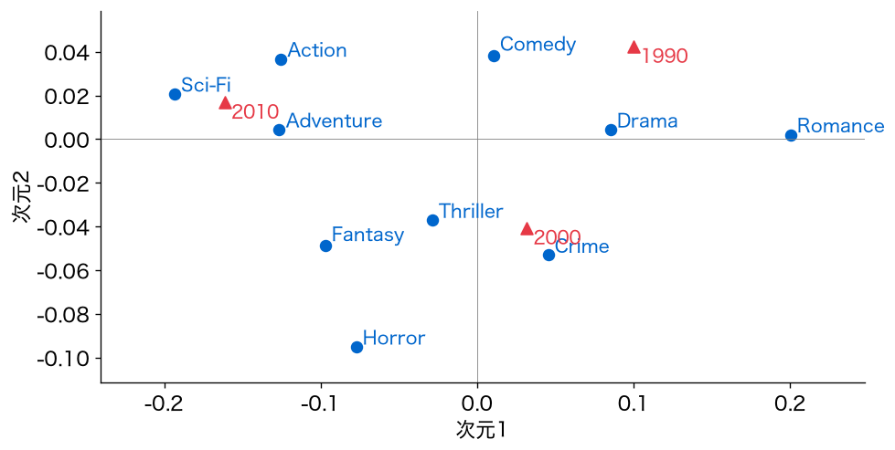

- 右に1990年代とロマンス・ドラマ、左に2010年代とSF・冒険もの・アクション

## 絞った倍率

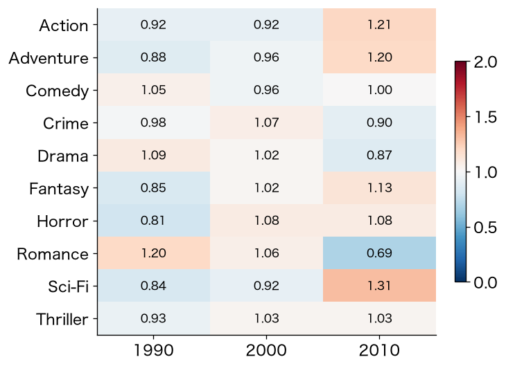

- 1990年代のロマンスは1.20倍、2010年代のSFは1.31倍、アクションは1.21倍

## 応用②：次元1の寄与率

```python
share2 = d2 ** 2 / (d2 ** 2).sum()
print('答え:', round(share2[0] * 100, 1))
```

```
答え: 88.8
```

- 9つの年代のとき（67.3%）より高い。年代が3つなので、ずれの向きが少ない

## 応用③：模範例

1990年代以降の3つの年代に絞っても、次元1は時代の軸のままで、ずれの88.8%を表します。1990年代とロマンス・ドラマが右に、2010年代とSF・冒険もの・アクションが左に並びます。倍率で見ると、1990年代はロマンスが1.20倍、2010年代はSFが1.31倍・アクションが1.21倍で、9つの年代のときより1から離れる幅は小さいものの、偏りは残っています。1990年代の特集はロマンス、2010年代の特集はSFとアクションを中心にすれば、最近の年代でも時代らしさを出せると思います。

## 書き方の型

- 1文目：絞った地図で、何が変わり、何が残ったか
- 2文目：倍率の数で確かめる
- 3文目：企画として、どうするか